# Load Data

```python
import pandas as pd

user_demographics = pd.read_csv('https://storage.googleapis.com/datalynn-datasets/interview-challenge/technology/Meta_Facebook_videos_recommendation/user_demographics.csv')
video_metadata = pd.read_csv('https://storage.googleapis.com/datalynn-datasets/interview-challenge/technology/Meta_Facebook_videos_recommendation/video_metadata.csv')
user_activity = pd.read_csv('https://storage.googleapis.com/datalynn-datasets/interview-challenge/technology/Meta_Facebook_videos_recommendation/user_activity.csv')
```

# Solution

## Question 1:

**Scenario:** Meta wants to optimize the recommendation system. To do this, it's essential to understand which genres are trending and resonate more with the users. Using the data tables provided, analyze the user engagement patterns and identify the top 3 genres that have the highest average watch time over the last month.

**Hints:**

1. **Filter Data:** Filter the `user_activity` table to only include data from the last month.
2. **Join Tables:** Join the filtered data from `user_activity` with the `video_metadata` table on the `video_id` to get the genre of each video.
3. **Aggregate Data:** Group by the genre and calculate the average watch time.
4. **Sort and Select Data:** Sort the genres by their average watch time in descending order and pick the top 3.

```python
import sqlite3
import pandas as pd

# Connect to an in-memory SQLite database
conn = sqlite3.connect(":memory:")

# Load the dataframes into SQLite data tables
user_activity.to_sql('user_activity', conn, if_exists='replace')
video_metadata.to_sql('video_metadata', conn, if_exists='replace')
user_demographics.to_sql('user_demographics', conn, if_exists='replace')

# Write the SQL query to find the top 3 genres with the highest average watch time over the last month
sql_query = """
    WITH LastMonthData AS (
        SELECT *
        FROM user_activity
        WHERE date >= DATE('now', '-1 months')
    )

    SELECT v.genre,
           AVG(u.watch_time) AS average_watch_time
    FROM LastMonthData u
    JOIN video_metadata v ON u.video_id = v.video_id
    GROUP BY v.genre
    ORDER BY average_watch_time DESC
    LIMIT 3;
"""

# Execute the query and print out the result
top_genres = pd.read_sql_query(sql_query, conn)
print(top_genres)
```

```
         genre  average_watch_time
0       Comedy         1920.068182
1  Documentary         1881.878788
2        Drama         1865.093750
```

## Question 2:

**Scenario:** Meta believes there's a strong correlation between user engagement metrics (like watch time, likes, and shares) and the demographics of a user. Given the data provided, can you determine if users in a particular age group or gender are more likely to engage with specific genres of content?

**Hints for Retrieve Desired Data:**

To answer this, we should consider the following steps:

1. **Join Tables**: We'll join the `user_activity` table with both the `video_metadata` and `user_demographics` tables to get the genre of each video as well as the demographic information of each user.
2. **Aggregate Data**: Group the data by `genre`, `age`, and `gender`. For each combination, we'll calculate the average watch time, percentage of likes, and percentage of shares.
3. **Analyze Result**: Analyze the data to find any noticeable patterns in user engagement based on age groups or gender across different genres.

```python
import sqlite3
import pandas as pd

# Connect to an in-memory SQLite database (assuming you've already connected from the previous question)
# conn = sqlite3.connect(":memory:")

# Write the SQL query
sql_query = """
    SELECT
           v.genre,
           d.age,
           d.gender,
           AVG(u.watch_time) AS average_watch_time,
           SUM(CASE WHEN u.liked = 1 THEN 1 ELSE 0 END) * 1.0 / COUNT(u.user_id) AS like_percentage,
           SUM(CASE WHEN u.shared = 1 THEN 1 ELSE 0 END) * 1.0 / COUNT(u.user_id) AS share_percentage
    FROM user_activity u
    JOIN video_metadata v ON u.video_id = v.video_id
    JOIN user_demographics d ON u.user_id = d.user_id
    GROUP BY v.genre, d.age, d.gender
    ORDER BY v.genre, d.age, d.gender;
"""

# Execute the query and print out the result
engagement_patterns = pd.read_sql_query(sql_query, conn)
engagement_patterns.head()
```

|  | genre | age | gender | average_watch_time | like_percentage | share_percentage |
| --- | --- | --- | --- | --- | --- | --- |
| 0 | Action | 14 | F | 1296.0 | 1.0 | 0.0 |
| 1 | Action | 14 | M | 1551.0 | 0.0 | 0.0 |
| 2 | Action | 14 | Other | 2034.0 | 0.0 | 0.0 |
| 3 | Action | 15 | F | 1168.0 | 0.0 | 0.0 |
| 4 | Action | 15 | M | 2177.0 | 0.0 | 0.0 |

**Hints for Groups Visualiztion**

1. **Define Age Groups**: Categorize the age data into several meaningful age groups (e.g., '18-24', '25-34', '35-44', '45-54', '55+').
2. **Define Gender Groups**: While there are multiple ways to categorize gender, for simplicity, we'll keep it as 'M', 'F', and 'Other'.
3. **Calculate Engagement Metrics by Group**: For each combination of age group, gender group, and genre, we'll calculate the average watch time, like percentage, and share percentage.
4. **Visualize the Data**: Plot the engagement metrics to visually understand the patterns.

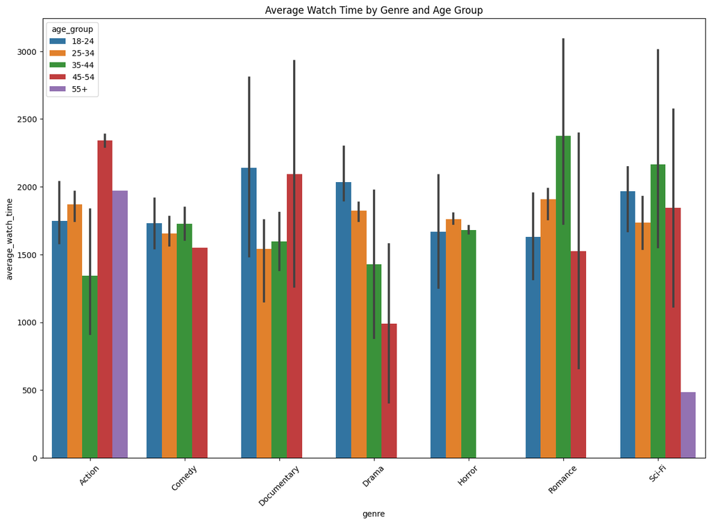

```python
# Define Gender Groups
def categorize_age(age):
    if age <= 24:
        return '18-24'
    elif age <= 34:
        return '25-34'
    elif age <= 44:
        return '35-44'
    elif age <= 54:
        return '45-54'
    else:
        return '55+'

engagement_patterns['age_group'] = engagement_patterns['age'].apply(categorize_age)

# Calculate Engagement Metrics by Group
grouped_engagement = engagement_patterns.groupby(['genre', 'age_group', 'gender']).agg({
    'average_watch_time': 'mean',
    'like_percentage': 'mean',
    'share_percentage': 'mean'
}).reset_index()

# Visualize the Data:
import matplotlib.pyplot as plt
import seaborn as sns

# For the sake of illustration, let's plot the average watch time for each genre by age group.
plt.figure(figsize=(15, 10))
sns.barplot(data=grouped_engagement, x='genre', y='average_watch_time', hue='age_group')
plt.title('Average Watch Time by Genre and Age Group')
plt.xticks(rotation=45)
plt.show()
```

## Question 3

**Progressive Scenario:** Content creators have expressed interest in understanding their content's reach. Taking the top genre identified in Question 1, determine which content creator has the most reach (measured by unique viewers) within that genre. Additionally, for this content creator, provide insights into the demographics of their viewership (age distribution, gender distribution).

**Hints:**

1. Identify the top genre from Question 1 ("Comedy" for the sake of this solution).
2. Filter the `video_metadata` dataframe for videos of the top genre ("Comedy").
3. Join the filtered `video_metadata` dataframe with the `user_activity` dataframe to get the user activity related to videos of the top genre.
4. Determine the content creator with the most reach by counting unique viewers (user_id) for each content creator.
5. For this top content creator, join with the `user_demographics` dataframe to get viewer demographics.
6. Provide insights into the demographics of their viewership by plotting age distribution and gender distribution.

```
Top content creator in the genre Comedy is 92 with 14 unique viewers.
```

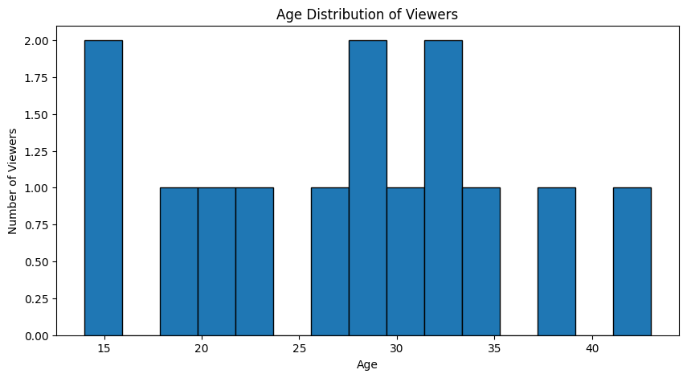

```
The age distribution plot shows the range of ages that viewers of the top content creator belong to. Peaks in the plot indicate age ranges with the most viewers.
```

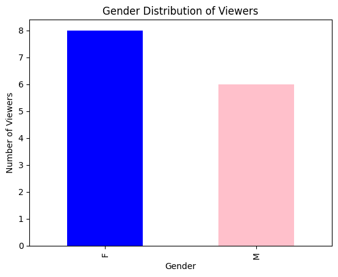

```
The gender distribution bar chart shows the number of viewers for each gender. This provides insights into which gender predominates the viewership of the top content creator.
```

```python
import pandas as pd
import matplotlib.pyplot as plt

# 1. Identify top genre
top_genre = "Comedy"

# 2. Filter video_metadata dataframe for videos of the top genre
top_genre_videos = video_metadata[video_metadata['genre'] == top_genre]

# 3. Join with user_activity dataframe
merged_df = pd.merge(user_activity, top_genre_videos, on='video_id')

# 4. Determine content creator with the most unique viewers
content_creator_reach = merged_df.groupby('creator_id').user_id.nunique().reset_index()
content_creator_reach = content_creator_reach.sort_values(by='user_id', ascending=False)
top_content_creator_id = content_creator_reach.iloc[0]['creator_id']

print(f"Top content creator in the genre {top_genre} is {top_content_creator_id} with {content_creator_reach.iloc[0]['user_id']} unique viewers.")

# 5. Get viewer demographics for top content creator
top_creator_activity = merged_df[merged_df['creator_id'] == top_content_creator_id]
viewer_demographics = pd.merge(top_creator_activity, user_demographics, on='user_id')

# 6. Insights into the demographics of their viewership
# a. Age distribution
plt.figure(figsize=(10,5))
viewer_demographics['age'].hist(bins=15, edgecolor='black')
plt.title('Age Distribution of Viewers')
plt.xlabel('Age')
plt.ylabel('Number of Viewers')
plt.grid(False)
plt.show()

print("The age distribution plot shows the range of ages that viewers of the top content creator belong to. Peaks in the plot indicate age ranges with the most viewers.")

# b. Gender distribution
gender_distribution = viewer_demographics['gender'].value_counts()
gender_distribution.plot(kind='bar', color=['blue', 'pink', 'green'])
plt.title('Gender Distribution of Viewers')
plt.xlabel('Gender')
plt.ylabel('Number of Viewers')
plt.show()

print("The gender distribution bar chart shows the number of viewers for each gender. This provides insights into which gender predominates the viewership of the top content creator.")
```

## Question 4

**Scenario:** There's a hypothesis that older videos (more than 6 months old) on Facebook Watch see a decline in user engagement. To validate or refute this, calculate the average watch time of videos based on their age (freshness since upload).

**Hints:**

1. Calculate the age (in months) of each video based on its uploaded date compared to a reference date (assuming the latest date in the dataset or today's date if not provided).
2. Categorize videos into two categories: "Fresh" (≤ 6 months old) and "Old" (> 6 months old).
3. Merge the age categories with the `user_activity` dataframe to get watch times associated with each video age category.
4. Calculate the average watch time for each category.
5. Visualize the results for better interpretation.

```
  age_category   watch_time
0        Fresh  1806.351955
1          Old  1790.762896
```

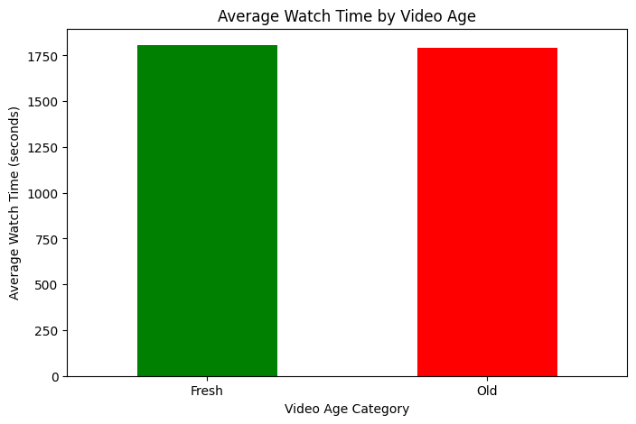

```python
import pandas as pd
import matplotlib.pyplot as plt

# 1. Calculate the age of each video
# Assuming we use the latest date in the dataset as the reference date
user_activity['date'] = pd.to_datetime(user_activity['date'] )
reference_date = max(user_activity['date'])

video_metadata['uploaded_date'] = pd.to_datetime(video_metadata['uploaded_date'])
video_metadata['video_age_months'] = (reference_date - video_metadata['uploaded_date']) / pd.Timedelta(30, 'D')

# 2. Categorize videos based on their age
video_metadata['age_category'] = ['Fresh' if age <= 6 else 'Old' for age in video_metadata['video_age_months']]

# 3. Merge with user_activity dataframe
merged_df = pd.merge(user_activity, video_metadata[['video_id', 'age_category']], on='video_id')

# 4. Calculate the average watch time for each category
avg_watch_time = merged_df.groupby('age_category')['watch_time'].mean().reset_index()

print(avg_watch_time)

# 5. Visualize the results
plt.figure(figsize=(8,5))
avg_watch_time.set_index('age_category')['watch_time'].plot(kind='bar', color=['green', 'red'])
plt.title('Average Watch Time by Video Age')
plt.xlabel('Video Age Category')
plt.ylabel('Average Watch Time (seconds)')
plt.xticks(rotation=0)
plt.show()
```